# **Assignment 3**: OpenAlex API and AI Research

Ladin Toplu

In this assignment, I use the OpenAlex API to explore research on artificial intelligence. I focus on publications with the phrase “artificial intelligence” in their titles and look at how much research has been published, where it comes from, which publications have received the most citations, and how publication trends have changed over time.

## **Summary of Findings**

- As of 2 October 2026, OpenAlex contains more than 330,000 works with “artificial intelligence” in the title.
- AI research has grown dramatically over time, especially in the last four years.
- The growth is much larger than what I see for a more established research topic like fertility.
- The United States, China, and India have the largest numbers of AI publications since 2000.
- Looking at AI publications as a share of each country's overall recent research output produces a different picture: Jordan, the United Arab Emirates, and Morocco have some of the highest shares among countries with at least 50,000 publications.

### Loading libraries

```python
import requests
import json
import jmespath
import pandas as pd
import matplotlib.pyplot as plt
import plotly.express as px
import plotly.io as pio
pio.renderers.default = "notebook"
```

### Question 1: Works with “artificial intelligence” in the title

I first searched the OpenAlex Works API for publications containing the phrase “artificial intelligence” in their titles. I also checked the first few titles returned by the API to make sure the search was actually returning what I intended it to.

```python
# API key for OpenAlex
api_key = "4BPk4yFuPyylMXKwbi6XyJ"

# define url for works with "artificial intelligence" in the title
openalex_ai_url = (
    'https://api.openalex.org/works?'
    'filter=title.search:"artificial intelligence"')

# get JSON data from the API
search_results = requests.get(
    openalex_ai_url,
    headers={"Authorization": f"Bearer {api_key}"}).json()

# number of works with "artificial intelligence" in the title
print(search_results["meta"]["count"])

# quality check: the titles of the first few results
titles = jmespath.search(
    'results[*].title',
    search_results)

print(titles[:5])
```

```
333848
['Artificial intelligence: a modern approach', 'Artificial intelligence: A modern approach', 'Lecture Notes in Artificial Intelligence', 'High-performance medicine: the convergence of human and artificial intelligence', 'Explainable Artificial Intelligence (XAI): Concepts, taxonomies, opportunities …
```

According to the OpenAlex Works API, there are 333848 works with the phrase “artificial intelligence” in their titles. As a quality check, I looked at the first five titles and confirmed that each contained “artificial intelligence".

### Question 2: Countries that published the most AI research since 2000

I first search OpenAlex for publications with “artificial intelligence” in the title that were published since 2000. I group these publications by the countries associated with the authors’ institution, which gives me a publication count for each country. I then turn the country-level results from the JSON object into a dataframe, keep the country names and publication counts, and sort the dataframe from highest to lowest. Finally, I make a table showing the top 10 countries with the largest number of AI publications, since listing all countries would be too much for one table.

```python
# URL to search for works with "artificial intelligence" in the title,
# published since 2000, grouped by country of the authors' affiliations
url_openalex_ai_2000_country = (
    'https://api.openalex.org/works?'
    'filter=title.search:"artificial intelligence",'
    'from_publication_date:2000-01-01'
    '&group_by=authorships.countries')

# get JSON data from the API
search_results_ai_2000_country = requests.get(
    url_openalex_ai_2000_country,
    headers={"Authorization": f"Bearer {api_key}"}).json()

# quality check: check the first five country groups returned by the API
# print(search_results_ai_2000_country["group_by"][:5])

# convert the country groups to a dataframe
df_ai_country = pd.DataFrame(
    search_results_ai_2000_country["group_by"])

# keep the country name and publication count
df_ai_country = df_ai_country[
    ["key_display_name", "count"]]

# rename the columns
df_ai_country = df_ai_country.rename(columns={
    "key_display_name": "Country",
    "count": "Number of Publications"})

# sort countries from highest to lowest number of publications
df_ai_country = df_ai_country.sort_values(
    by="Number of Publications",
    ascending=False)

# quality check: check for missing values
# print(df_ai_country.isnull().sum())

# quality check: check the number of country groups
# print("Number of countries:", len(df_ai_country))

# top 10 countries with the most AI publications
(df_ai_country.head(10)
    .style
    .hide(axis="index")
    .set_caption(
        "Table 1. Countries with the most AI publications since 2000")
    .format({
        "Number of Publications": "{:,.0f}"}))
```

Table 1. Countries with the most AI publications since 2000

| Country | Number of Publications |
| --- | --- |
| United States | 37,241 |
| China | 30,124 |
| India | 25,011 |
| United Kingdom | 12,734 |
| Indonesia | 9,434 |
| Italy | 7,470 |
| Germany | 6,925 |
| Turkey | 6,718 |
| Russia | 5,968 |
| Canada | 5,915 |

### Question 3: The 10 most highly cited AI publications since 2000

For this question, I first search for publications with “artificial intelligence” in the title since 2000 and sort them by their citation counts. I keep the 10 most highly cited publications and extract their titles, citation counts, authors, and institutions. I then show this information in a table.

```python
# URL to search for works with "artificial intelligence" in the title,
# published since 2000, sorted by citation count
url_openalex_ai_cited = (
    'https://api.openalex.org/works?'
    'filter=title.search:"artificial intelligence",'
    'from_publication_date:2000-01-01'
    '&sort=cited_by_count:desc'
    '&per-page=10')

# get JSON data from the API
search_results_ai_cited = requests.get(
    url_openalex_ai_cited,
    headers={"Authorization": f"Bearer {api_key}"}).json()


# quality check: examine the citation counts
# citation_counts = jmespath.search(
#    'results[*].cited_by_count',
#    search_results_ai_cited)
# print(citation_counts)

# the titles of the 10 most highly cited works
titles = jmespath.search(
    'results[*].title',
    search_results_ai_cited)

# citation counts
citations = jmespath.search(
    'results[*].cited_by_count',
    search_results_ai_cited)

# the authors for each of the 10 works
authors = jmespath.search(
    'results[*].authorships[*].author.display_name',
    search_results_ai_cited)

# the institutions of the authors of each work
institutions = jmespath.search(
    'results[*].authorships[*].institutions[*].display_name',
    search_results_ai_cited)

# quality check: examine the authors and institutions for the first work
# print("Title:", titles[0])
# print("Authors:", authors[0])
# print("Institutions:", institutions[0])
```

```python
# empty lists for the author and institution names
authors_clean = []
institutions_clean = []

# loop through the authors for each work
for author_list in authors:
    authors_clean.append(", ".join(author_list))

# loop through the institutions for each work
for institution_list in institutions:

    work_institutions = []

    for author_institutions in institution_list:
        for institution in author_institutions:
            if institution not in work_institutions:
                work_institutions.append(institution)

    institutions_clean.append(", ".join(work_institutions))

# 10 most highly cited works
df_ai_cited = pd.DataFrame({
    "Title": titles,
    "Citations": citations,
    "Authors": authors_clean,
    "Institutions": institutions_clean})

(df_ai_cited
    .style
    .hide(axis="index")
    .set_caption(
        "Table 2. Top 10 cited AI publications since 2000")
    .format({"Citations": "{:,.0f}"}))
```

Table 2. Top 10 cited AI publications since 2000

| Title | Citations | Authors | Institutions |
| --- | --- | --- | --- |
| High-performance medicine: the convergence of human and artificial intelligence | 10,279 | Eric J. Topol | Scripps Research Institute |
| Explainable Artificial Intelligence (XAI): Concepts, taxonomies, opportunities and challenges toward responsible AI | 10,137 | Alejandro Barredo Arrieta, Natalia Díaz-Rodríguez, Javier Del Ser, Adrien Bennetot, Siham Tabik, Alberto Barbado, Salvador García, Sergio Gil-López, Daniel Molina, Richard Benjamins, Raja Chatila, Fra… | Tecnalia, Institut national de recherche en sciences et technologies du numérique, École Nationale Supérieure de Techniques Avancées, École Nationale Supérieure de Techniques Avancées Paris, Unité d'I… |
| Systematic review of research on artificial intelligence applications in higher education – where are the educators? | 6,847 | Olaf Zawacki‐Richter, Victoria I. Marín, Melissa Bond, Franziska Gouverneur | Carl von Ossietzky Universität Oldenburg |
| Peeking Inside the Black-Box: A Survey on Explainable Artificial Intelligence (XAI) | 6,290 | Amina Adadi, Mohammed Berrada | Sidi Mohamed Ben Abdellah University |
| Proceedings of the 19th International Joint Conference on Artificial Intelligence | 5,781 | Josep M. Pujol, Jordi Delgado, Ramón Sangüesa, Andreas Flache |  |
| Explanation in artificial intelligence: Insights from the social sciences | 5,266 | Tim Miller | The University of Melbourne |
| Artificial intelligence in healthcare: past, present and future | 4,901 | Fei Jiang, Yong Jiang, Hui Zhi, Yi Dong, Hao Li, Sufeng Ma, Yilong Wang, Yilong Wang, Qiang Dong, Haipeng Shen, Yongjun Wang, Yongjun Wang | University of Hong Kong, Capital Medical University, Beijing Tian Tan Hospital, Fudan University, Huashan Hospital |
| Artificial Intelligence (AI): Multidisciplinary perspectives on emerging challenges, opportunities, and agenda for research, practice and policy | 4,526 | Yogesh Kumar Dwivedi, Laurie Hughes, Elvira Ismagilova, Gert Aarts, Crispin R. Coombs, Tom Crick, Yanqing Duan, Rohita Dwivedi, John Steven Edwards, Aled Eirug, Vassilis Galanos, P. Vigneswara Ilavara… | Prin. L. N. Welingkar Institute of Management Development and Research, Swansea University, University of Bradford, Loughborough University, University of Bedfordshire, Aston University, University of… |
| BNAI, NO-TOKEN, and MIND-UNITY: Pillars of a Systemic Revolution in Artificial Intelligence | 4,271 | Wei, Jason, Wang, Xuezhi, Dale Schuurmans, Maarten Bosma, Ichter, Brian, Xia, Fei, Ed H., Quoc Viet Le, Denny Zhou | Google (United States) |
| Artificial Intelligence in Education: A Review | 3,983 | Lijia Chen, Pingping Chen, Zhijian Lin | Yango University, Fuzhou University |

The 10 most highly cited papers have between 3,983 and 10,279 citations. The most highly cited is *High-performance medicine: the convergence of human and artificial intelligence* by Eric J. Topol, who is affiliated with the Scripps Research Institute, with 10,279 citations. It is followed very closely by *Explainable Artificial Intelligence (XAI)* with 10,137 citations. The table above provides the titles, citation counts, authors, and institutional affiliations for all 10 papers.

### Question 4: Publication trends over time

For this question, I compare publication trends for four keywords from 2000 to 2026. I use “artificial intelligence” as the main topic and include LLM and GPT to see how newer AI-related terms have changed over time. I also include fertility as a comparison because it is a more established research topic and gives me something outside of AI to compare the trends against. For each keyword, I use a loop to get the number of publications in each year, combine the results into a dataframe, and then plot the time trends on the same graph.

```python
# list of keywords
keywords = ["artificial intelligence", "LLM", "GPT", "fertility"]

# range of years from 2000 to 2026
years = range(2000, 2027)

# empty lists to store the results
keyword_list = []
year_list = []
count_list = []

# loop through each keyword
for keyword in keywords:

    # loop through each year
    for year in years:

        # OpenAlex URL for the keyword and publication year
        url = f'https://api.openalex.org/works?filter=title.search:"{keyword}",publication_year:{year}'

        # get JSON data from the API
        search_results = requests.get(
            url,
            headers={"Authorization": f"Bearer {api_key}"}
        ).json()

        keyword_list.append(keyword)
        year_list.append(year)
        count_list.append(search_results["meta"]["count"])

# dataframe with the year x publication counts
df_keywords = pd.DataFrame({
    "Year": year_list,
    "Keyword": keyword_list,
    "Number of publications": count_list})

# quality check: display the first few rows
# df_keywords.head()

# quality check: confirm the expected number of observations
# print("Number of observations:", len(df_keywords))

# quality check: check for missing values
# print(df_keywords.isnull().sum())
```

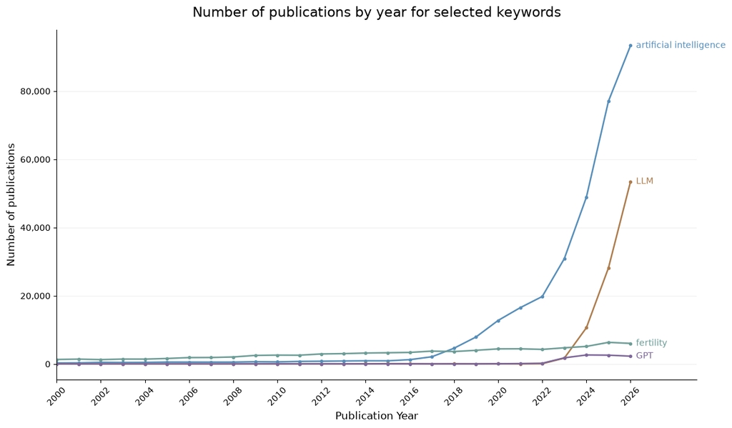

```python
# colors for each keyword
colors = {
    "artificial intelligence": "#568EB9",
    "LLM": "#AC7C4D",
    "GPT": "#7D6799",
    "fertility": "#6D9D97"}

# a line graph of publications by year for each keyword
plt.figure(figsize=(12, 7))

# loop through each keyword
for keyword in keywords:

    df_keyword = df_keywords[df_keywords["Keyword"] == keyword]

    # plot the number of publications by year
    plt.plot(
        df_keyword["Year"],
        df_keyword["Number of publications"],
        linewidth=1.8,
        marker="o",
        markersize=3,
        color=colors[keyword])

    # add the keyword next to the end of its line
    plt.text(
        df_keyword["Year"].iloc[-1] + 0.25,
        df_keyword["Number of publications"].iloc[-1],
        keyword,
        color=colors[keyword],
        fontsize=10,
        va="center")

# add title and axis labels
plt.title(
    "Number of publications by year for selected keywords",
    fontsize=16,
    pad=15)

plt.xlabel("Publication Year", fontsize=12)
plt.ylabel("Number of publications", fontsize=12)

# show every other year on the x-axis
plt.xticks(
    range(2000, 2027, 2),
    rotation=45)

# add a light horizontal grid
plt.grid(
    axis="y",
    alpha=0.2)

ax = plt.gca()
ax.spines["top"].set_visible(False)
ax.spines["right"].set_visible(False)
from matplotlib.ticker import StrMethodFormatter
ax.yaxis.set_major_formatter(StrMethodFormatter("{x:,.0f}"))
plt.xlim(2000, 2029)
plt.tight_layout()
plt.show()
```

Publications with “artificial intelligence” in the title started increasing around 2017 and then grew very quickly after 2022, reaching more than 90,000 publications in 2026. The increase of LLM is more recent and dramatic, going from almost no publications before 2022 to more than 50,000 in 2026. GPT also increases after 2022 but its increase is a lot less dramatic than articifical intelligence or LLM. I chose fertility as a comparison since it's a more established research field that has been around for a longer time. The difference is clear: For fertility, publications increase much more gradually over the entire period and remain relatively stable in the most recent years. By including fertility, I show just how recent and rapid the growth in AI-related publishing has been compared with a more established research topic.

### Questions 5 and 6: Countries that are most oriented toward AI research

For my additional analysis, I wanted to take Question 2 a step further. Countries vary enormously in how much research they produce overall, so a country could publish a large number of AI papers simply because it publishes a large number of papers in general. So instead, I will be mapping countries' share of their recent research devoted to artificial intelligence.

I focus on 2022–2026, because I am interested in the period when AI-related publishing grew most rapidly, and according to Question 4, this is after 2022. I calculate the number of publications with “artificial intelligence” in the title as a percentage of all publications associated with each country. I exclude countries with fewer than 50,000 total publications during this period because very small publication counts produced some unusually large percentages based on only a handful of AI papers. I then map the resulting percentages to show how the relative prominence of AI research varies geographically.

```python
# all publications from 2022-2026, grouped by country
url_all_country = (
    'https://api.openalex.org/works?'
    'filter=publication_year:2022-2026'
    '&group_by=authorships.countries')

all_country_results = requests.get(
    url_all_country,
    headers={"Authorization": f"Bearer {api_key}"}).json()

df_all_country = pd.DataFrame(
    all_country_results["group_by"]
)[["key", "key_display_name", "count"]]

df_all_country = df_all_country.rename(columns={
    "key": "Country Code",
    "key_display_name": "Country",
    "count": "All Publications"})

# AI publications from 2022-2026, grouped by country
url_ai_country = (
    'https://api.openalex.org/works?'
    'filter=title.search:"artificial intelligence",'
    'publication_year:2022-2026'
    '&group_by=authorships.countries')

ai_country_results = requests.get(
    url_ai_country,
    headers={"Authorization": f"Bearer {api_key}"}).json()

df_ai_country_recent = pd.DataFrame(
    ai_country_results["group_by"])[["key", "key_display_name", "count"]]

df_ai_country_recent = df_ai_country_recent.rename(columns={
    "key": "Country Code",
    "key_display_name": "Country",
    "count": "AI Publications"})
```

```python
# merge the two dataframes by country
df_ai_share = df_all_country.merge(
    df_ai_country_recent,
    on=["Country Code", "Country"],
    how="left")

# countries with no AI publications receive a count of 0
df_ai_share["AI Publications"] = (
    df_ai_share["AI Publications"].fillna(0))

# calculate AI publications as a percentage of all publications
df_ai_share["AI Share"] = (
    df_ai_share["AI Publications"]
    / df_ai_share["All Publications"]) * 100

# keep countries with at least 50,000 total publications
df_ai_share_filtered = df_ai_share[
    df_ai_share["All Publications"] >= 50000].copy()

# final table
df_ai_share_table = (
    df_ai_share_filtered
    .sort_values(by="AI Share", ascending=False)
    [[
        "Country",
        "All Publications",
        "AI Publications",
        "AI Share"
    ]]
    .head(20))

(df_ai_share_table
    .style
    .hide(axis="index")
    .set_caption(
        "Table 3. Countries with the highest share of AI publications, 2022–2026")
    .format({
        "All Publications": "{:,.0f}",
        "AI Publications": "{:,.0f}",
        "AI Share": "{:.2f}%"}))
```

Table 3. Countries with the highest share of AI publications, 2022–2026

| Country | All Publications | AI Publications | AI Share |
| --- | --- | --- | --- |
| Jordan | 80,950 | 1,524 | 1.88% |
| United Arab Emirates | 123,008 | 1,866 | 1.52% |
| Morocco | 120,710 | 1,674 | 1.39% |
| Romania | 152,447 | 1,909 | 1.25% |
| Nigeria | 279,262 | 3,405 | 1.22% |
| Saudi Arabia | 412,776 | 4,467 | 1.08% |
| Malaysia | 349,322 | 3,748 | 1.07% |
| Philippines | 124,987 | 1,324 | 1.06% |
| Bulgaria | 61,493 | 636 | 1.03% |
| India | 2,172,601 | 22,306 | 1.03% |
| Uzbekistan | 182,623 | 1,859 | 1.02% |
| Pakistan | 335,099 | 3,228 | 0.96% |
| Kazakhstan | 83,167 | 777 | 0.93% |
| Greece | 185,816 | 1,713 | 0.92% |
| Serbia | 79,268 | 724 | 0.91% |
| Iraq | 222,357 | 1,880 | 0.85% |
| Bangladesh | 159,788 | 1,313 | 0.82% |
| Turkey | 747,803 | 6,096 | 0.82% |
| Ghana | 59,795 | 476 | 0.80% |
| Algeria | 83,092 | 621 | 0.75% |

```python
# Create a world map showing AI publications as a percentage
# of each country's total research output
fig = px.choropleth(
    df_ai_share_filtered,
    locations="Country",
    locationmode="country names",
    color="AI Share",
    hover_name="Country",
    hover_data={
        "All Publications": ":,",
        "AI Publications": ":,.0f",
        "AI Share": ":.2f"},
    labels={
        "AI Share": "AI Share (%)"},
    color_continuous_scale="Purples")

fig.update_layout(
    title={
        "text": "Artificial Intelligence as a Share of Scholarly Research, 2022–2026",
        "x": 0.5},
    coloraxis_colorbar=dict(
        title="AI Share (%)"),
    margin=dict(
        l=0,
        r=0,
        t=60,
        b=0))

fig.update_geos(
    showframe=False,
    showcoastlines=True,
    projection_type="natural earth")
```

[interactive chart not shown]

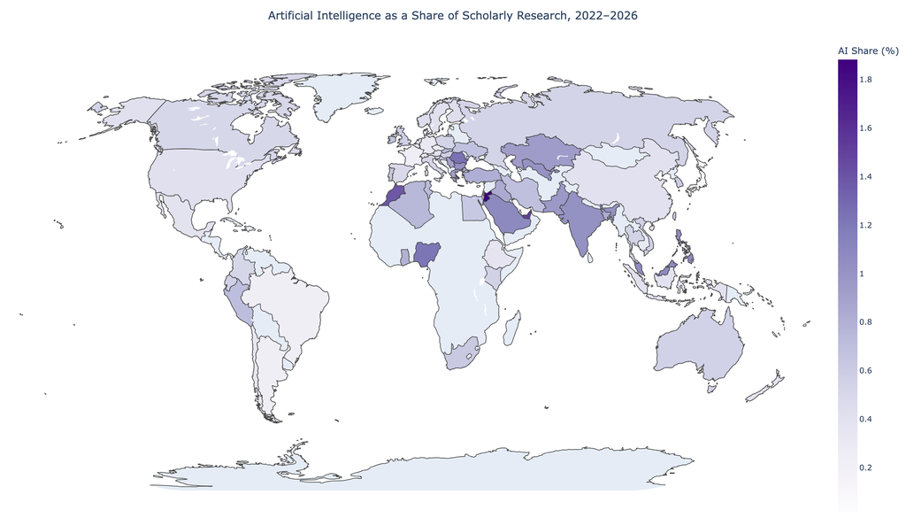

```python
# Save the map as a static image
fig.write_image(
    "ai_research_map.png",
    width=1400,
    height=800,
    scale=2
)

# Display the static image
from IPython.display import Image, display
display(Image(filename="ai_research_map.png"))
```

Among countries with at least 50,000 publications, Jordan has the highest share, with about 1.88% of its publications from 2022–2026 having “artificial intelligence” in the title. The United Arab Emirates and Morocco follow at about 1.52% and 1.39%. More broadly, relatively high shares appear across several countries in the Middle East, North Africa, and parts of Asia.

I would be a little cautious about interpreting these differences too strongly, though. My measure only captures publications that actually have the phrase “artificial intelligence” in their title, so it definitely does not capture all AI research. I also used a 50,000-publication cutoff because smaller research systems produced some very high percentages based on relatively few AI publications. So I see this map more as an interesting picture of where AI appears especially prominent in recent research output than as a definitive ranking of which countries are “most focused” on AI.